# Principal Component Analysis with Cancer Data

# Q9 Use PCA command from sklearn and find Principal Components. Transform data to components formed

```python
from sklearn.decomposition import PCA
```

```python
pca = PCA(n_components=6)
pca.fit(X_std)
```

```
PCA(copy=True, iterated_power='auto', n_components=6, random_state=None,
  svd_solver='auto', tol=0.0, whiten=False)
```

```python
X_pca = pca.transform(X_std)
```

```python
X_pca_df = pd.DataFrame(X_pca)
```

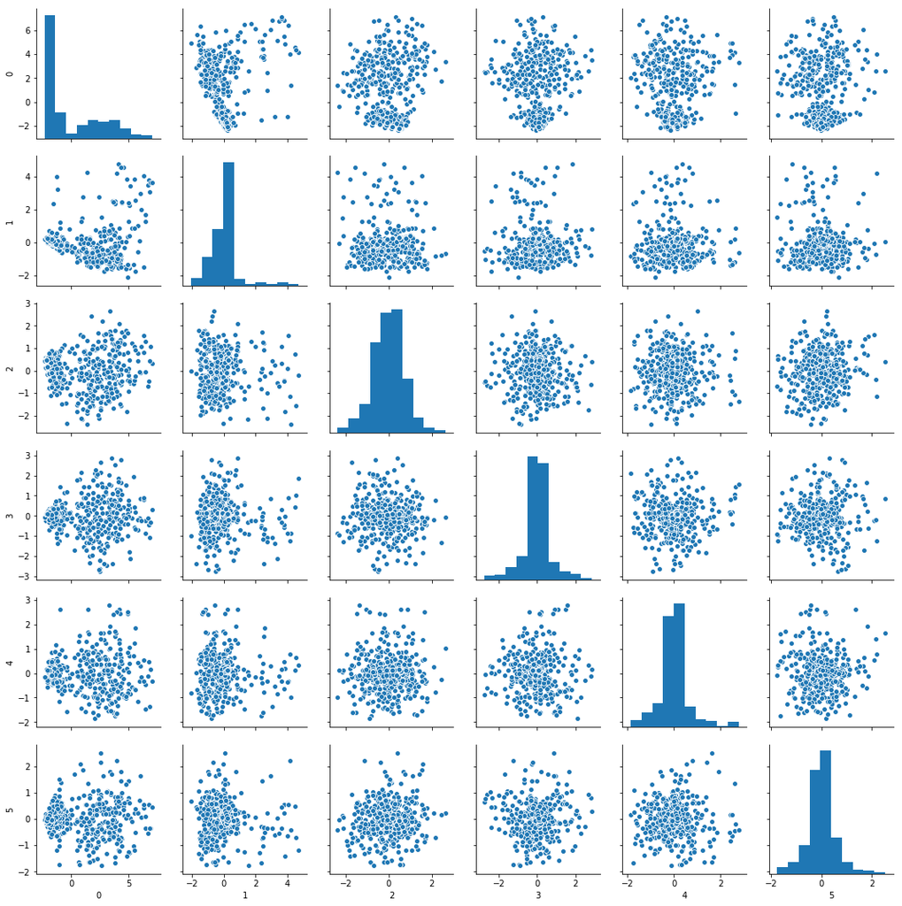

```python
sns.pairplot(X_pca_df)
```

# Q10 Find correlation between components and features

```python
rel_df = pd.DataFrame(pca.components_,columns=list(X))
rel_df
```

|  | Clump Thickness | Cell Size | Cell Shape | Marginal Adhesion | Single Epthelial Cell Size | Bare Nuclei | Normal Nucleoli | Bland Chromatin | Mitoses |
| --- | --- | --- | --- | --- | --- | --- | --- | --- | --- |
| 0 | 0.302805 | 0.381190 | 0.377574 | 0.332823 | 0.336391 | 0.333497 | 0.345956 | 0.335840 | 0.229818 |
| 1 | -0.146029 | -0.049564 | -0.085270 | -0.044719 | 0.164038 | -0.247710 | -0.229942 | 0.025027 | 0.908394 |
| 2 | -0.862217 | 0.019092 | -0.034584 | 0.421448 | 0.110104 | -0.003671 | 0.197449 | 0.131650 | -0.094593 |
| 3 | -0.088217 | 0.202639 | 0.175155 | -0.470317 | 0.373329 | -0.543177 | -0.006990 | 0.455372 | -0.239686 |
| 4 | -0.071928 | 0.137357 | 0.104691 | -0.034628 | 0.682582 | 0.127506 | -0.255191 | -0.631803 | -0.131627 |
| 5 | 0.269469 | 0.100098 | 0.032002 | 0.680834 | -0.035598 | -0.574866 | -0.314597 | -0.038416 | -0.143607 |

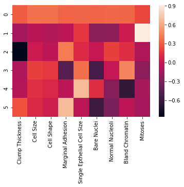

```python
sns.heatmap(rel_df)
```

# Popularity Based Recommendation System

### About Dataset

Anonymous Ratings on jokes.

1. Ratings are real values ranging from -10.00 to +10.00 (the value "99" corresponds to "null" = "not rated").
2. One row per user
3. The first column gives the number of jokes rated by that user. The next 100 columns give the ratings for jokes 01 - 100.

# Q11 Read the dataset(jokes.csv)

```python
jokes_df = pd.read_csv("jokes.csv")
```

```python
jokes_df.head()
```

|  | NumJokes | Joke1 | Joke2 | Joke3 | Joke4 | Joke5 | Joke6 | Joke7 | Joke8 | Joke9 | ... | Joke91 | Joke92 | Joke93 | Joke94 | Joke95 | Joke96 | Joke97 | Joke98 | Joke99 | Joke100 |
| --- | --- | --- | --- | --- | --- | --- | --- | --- | --- | --- | --- | --- | --- | --- | --- | --- | --- | --- | --- | --- | --- |
| 0 | 74 | -7.82 | 8.79 | -9.66 | -8.16 | -7.52 | -8.50 | -9.85 | 4.17 | -8.98 | ... | 2.82 | 99.00 | 99.00 | 99.00 | 99.00 | 99.00 | -5.63 | 99.00 | 99.00 | 99.00 |
| 1 | 100 | 4.08 | -0.29 | 6.36 | 4.37 | -2.38 | -9.66 | -0.73 | -5.34 | 8.88 | ... | 2.82 | -4.95 | -0.29 | 7.86 | -0.19 | -2.14 | 3.06 | 0.34 | -4.32 | 1.07 |
| 2 | 49 | 99.00 | 99.00 | 99.00 | 99.00 | 9.03 | 9.27 | 9.03 | 9.27 | 99.00 | ... | 99.00 | 99.00 | 99.00 | 9.08 | 99.00 | 99.00 | 99.00 | 99.00 | 99.00 | 99.00 |
| 3 | 48 | 99.00 | 8.35 | 99.00 | 99.00 | 1.80 | 8.16 | -2.82 | 6.21 | 99.00 | ... | 99.00 | 99.00 | 99.00 | 0.53 | 99.00 | 99.00 | 99.00 | 99.00 | 99.00 | 99.00 |
| 4 | 91 | 8.50 | 4.61 | -4.17 | -5.39 | 1.36 | 1.60 | 7.04 | 4.61 | -0.44 | ... | 5.19 | 5.58 | 4.27 | 5.19 | 5.73 | 1.55 | 3.11 | 6.55 | 1.80 | 1.60 |

5 rows × 101 columns

```python
jokes_df.shape
```

```
(24983, 101)
```

# Q12 Consider `ratings` named dataframe with only first 200 rows and all columns from 1(first column is 0) of dataset

```python
ratings_df= jokes_df.iloc[0:200, 1:]
ratings_df.head()
```

|  | Joke1 | Joke2 | Joke3 | Joke4 | Joke5 | Joke6 | Joke7 | Joke8 | Joke9 | Joke10 | ... | Joke91 | Joke92 | Joke93 | Joke94 | Joke95 | Joke96 | Joke97 | Joke98 | Joke99 | Joke100 |
| --- | --- | --- | --- | --- | --- | --- | --- | --- | --- | --- | --- | --- | --- | --- | --- | --- | --- | --- | --- | --- | --- |
| 0 | -7.82 | 8.79 | -9.66 | -8.16 | -7.52 | -8.50 | -9.85 | 4.17 | -8.98 | -4.76 | ... | 2.82 | 99.00 | 99.00 | 99.00 | 99.00 | 99.00 | -5.63 | 99.00 | 99.00 | 99.00 |
| 1 | 4.08 | -0.29 | 6.36 | 4.37 | -2.38 | -9.66 | -0.73 | -5.34 | 8.88 | 9.22 | ... | 2.82 | -4.95 | -0.29 | 7.86 | -0.19 | -2.14 | 3.06 | 0.34 | -4.32 | 1.07 |
| 2 | 99.00 | 99.00 | 99.00 | 99.00 | 9.03 | 9.27 | 9.03 | 9.27 | 99.00 | 99.00 | ... | 99.00 | 99.00 | 99.00 | 9.08 | 99.00 | 99.00 | 99.00 | 99.00 | 99.00 | 99.00 |
| 3 | 99.00 | 8.35 | 99.00 | 99.00 | 1.80 | 8.16 | -2.82 | 6.21 | 99.00 | 1.84 | ... | 99.00 | 99.00 | 99.00 | 0.53 | 99.00 | 99.00 | 99.00 | 99.00 | 99.00 | 99.00 |
| 4 | 8.50 | 4.61 | -4.17 | -5.39 | 1.36 | 1.60 | 7.04 | 4.61 | -0.44 | 5.73 | ... | 5.19 | 5.58 | 4.27 | 5.19 | 5.73 | 1.55 | 3.11 | 6.55 | 1.80 | 1.60 |

5 rows × 100 columns

# Q13 Change the column indices from 0 to 99

```python
ratings_df.columns = range(0,100)
```

```python
ratings_df.head()
```

|  | 0 | 1 | 2 | 3 | 4 | 5 | 6 | 7 | 8 | 9 | ... | 90 | 91 | 92 | 93 | 94 | 95 | 96 | 97 | 98 | 99 |
| --- | --- | --- | --- | --- | --- | --- | --- | --- | --- | --- | --- | --- | --- | --- | --- | --- | --- | --- | --- | --- | --- |
| 0 | -7.82 | 8.79 | -9.66 | -8.16 | -7.52 | -8.50 | -9.85 | 4.17 | -8.98 | -4.76 | ... | 2.82 | 99.00 | 99.00 | 99.00 | 99.00 | 99.00 | -5.63 | 99.00 | 99.00 | 99.00 |
| 1 | 4.08 | -0.29 | 6.36 | 4.37 | -2.38 | -9.66 | -0.73 | -5.34 | 8.88 | 9.22 | ... | 2.82 | -4.95 | -0.29 | 7.86 | -0.19 | -2.14 | 3.06 | 0.34 | -4.32 | 1.07 |
| 2 | 99.00 | 99.00 | 99.00 | 99.00 | 9.03 | 9.27 | 9.03 | 9.27 | 99.00 | 99.00 | ... | 99.00 | 99.00 | 99.00 | 9.08 | 99.00 | 99.00 | 99.00 | 99.00 | 99.00 | 99.00 |
| 3 | 99.00 | 8.35 | 99.00 | 99.00 | 1.80 | 8.16 | -2.82 | 6.21 | 99.00 | 1.84 | ... | 99.00 | 99.00 | 99.00 | 0.53 | 99.00 | 99.00 | 99.00 | 99.00 | 99.00 | 99.00 |
| 4 | 8.50 | 4.61 | -4.17 | -5.39 | 1.36 | 1.60 | 7.04 | 4.61 | -0.44 | 5.73 | ... | 5.19 | 5.58 | 4.27 | 5.19 | 5.73 | 1.55 | 3.11 | 6.55 | 1.80 | 1.60 |

5 rows × 100 columns

# Q14 In the dataset, the null ratings are given as 99.00, so replace all 99.00s with 0

Hint: You can use `ratings.replace(<the given value>, <new value you wanted to change with>)`

```python
ratings_df = ratings_df.replace(99,0)
```

```python
ratings_df.head()
```

|  | 0 | 1 | 2 | 3 | 4 | 5 | 6 | 7 | 8 | 9 | ... | 90 | 91 | 92 | 93 | 94 | 95 | 96 | 97 | 98 | 99 |
| --- | --- | --- | --- | --- | --- | --- | --- | --- | --- | --- | --- | --- | --- | --- | --- | --- | --- | --- | --- | --- | --- |
| 0 | -7.82 | 8.79 | -9.66 | -8.16 | -7.52 | -8.50 | -9.85 | 4.17 | -8.98 | -4.76 | ... | 2.82 | 0.00 | 0.00 | 0.00 | 0.00 | 0.00 | -5.63 | 0.00 | 0.00 | 0.00 |
| 1 | 4.08 | -0.29 | 6.36 | 4.37 | -2.38 | -9.66 | -0.73 | -5.34 | 8.88 | 9.22 | ... | 2.82 | -4.95 | -0.29 | 7.86 | -0.19 | -2.14 | 3.06 | 0.34 | -4.32 | 1.07 |
| 2 | 0.00 | 0.00 | 0.00 | 0.00 | 9.03 | 9.27 | 9.03 | 9.27 | 0.00 | 0.00 | ... | 0.00 | 0.00 | 0.00 | 9.08 | 0.00 | 0.00 | 0.00 | 0.00 | 0.00 | 0.00 |
| 3 | 0.00 | 8.35 | 0.00 | 0.00 | 1.80 | 8.16 | -2.82 | 6.21 | 0.00 | 1.84 | ... | 0.00 | 0.00 | 0.00 | 0.53 | 0.00 | 0.00 | 0.00 | 0.00 | 0.00 | 0.00 |
| 4 | 8.50 | 4.61 | -4.17 | -5.39 | 1.36 | 1.60 | 7.04 | 4.61 | -0.44 | 5.73 | ... | 5.19 | 5.58 | 4.27 | 5.19 | 5.73 | 1.55 | 3.11 | 6.55 | 1.80 | 1.60 |

5 rows × 100 columns

# Q15 Normalize the ratings using StandardScaler and save them in `ratings_diff` variable

```python
ratings_diff = StandardScaler().fit_transform(ratings_df)
ratings_diff
```

```
array([[-1.85701632,  1.67164929, -2.21918089, ..., -0.02685824,
        -0.04144395, -0.16095388],
       [ 0.78949409, -0.1802773 ,  1.3727099 , ...,  0.07059963,
        -1.36765027,  0.16746078],
       [-0.11788091, -0.12112987, -0.0532842 , ..., -0.02685824,
        -0.04144395, -0.16095388],
       ...,
       [ 0.46479617, -0.89412566, -0.3156133 , ..., -0.23610604,
         0.18266036, -0.02590486],
       [-0.11788091, -0.12112987, -0.0532842 , ..., -0.02685824,
        -0.04144395, -0.16095388],
       [ 1.12308784, -1.60593445, -1.07569506, ..., -0.02685824,
        -0.04144395, -0.16095388]])
```